# Lab 1

Robert McDonough

# Introduction

- My name is Robert, welcome to econometrics lab.
- This walkthrough is meant to serve as a supplement for the econometrics discussion from Wednesday, Week 1. As anyone who was there knows, we had some technical issues that made the first lab a little choppy. (Thanks, campus wifi).
- If you want to follow along with this document, open R studio and try copying the code I’ve got below into a blank R script. It should run pretty smoothly.
- You should be able to access the recording of that discussion section on Canvas.

# R Basics

Today we are going to cover the basics of working in R and RStudio. In order to work through this lab, you’ll need to have R and RStudio already installed. If you are not already familiar with the basic layout of RStudio, please watch the beginning of that Zoom recording (starting around minute 8) where I go through what you see when you open RStudio.

## Comments

The first thing we should cover is commenting. Commenting in any coding language is essential to writing good code. In plain language, a comment is a line of text or code that the computer skips over. In practice, this is how we write notes to ourselves and others about what our code is doing and how it works. We can write comments in R by starting a line with one or more ‘#’ symbols.

```r
##R is not going to run this line of code
```

## Running Code

Once we write a line of code that we actually want to use, we can get the computer to run that line of code by hitting ‘ctrl’+‘enter’ on a Windows device or ‘cmd’+‘return’ on a Mac.

We will be working with what is called a *script*. This is similar to a do file in Stata. It’s basically your workspace. It lets us write, run, and save as much code as we want.

- We can also write and run code from the command line. This is useful for small one-off things that we want to do (say, a quick bit of math), but is not as useful when it comes to bigger projects.

# Objects and Functions

## Lesson 1: All things are objects

Everything in R is an object, and every object has two components: a name, and a value. The name is always the same: a string of characters we choose which *cannot* start with a number or contain spaces. The value of an object can be almost anything. A value can be as simple as a number, or as complicated as a matrix (or even more complicated).

- Once we have some objects, we use functions to manipulate, interact with, create, or get rid of those objects. More on this shortly. First, let’s make some objects.

```r
# To make an object, we choose a name, then use the '<-' or '=' sign.
# Then, we put the value to the right of the '='.
x<-10
y=5
```

We can also do math with objects in R:

```r
a= x+y
a
```

```
## [1] 15
```

```r
b=x*y
b
```

```
## [1] 50
```

```r
c=y^x
c
```

```
## [1] 9765625
```

```r
d=x/y
d
```

```
## [1] 2
```

Note: when you run a line of code in R from a script, you’ll see that line of code pop up near the bottom of the console window. Unless an error message also shows up, this means R has run the line. (More on error messages in a second)

## Lesson 2: There are several types of objects

As I said, an object does not need to be a number. We can also make *character* objects (strings of text). Let’s give it a shot

```r
sentence= Robert needs a haircut.
```

```
## Error: <text>:1:18: unexpected symbol
## 1: sentence= Robert needs
##                      ^
```

Uh-oh. R didn’t like that…

## Error Messages

This gives us a good introduction to error messages. When we write code that R cannot understand, it will give us an error message. If we’re lucky, the error message makes sense. If not, we might have to do some googling to figure out what it means.

- In this case, I already know what’s wrong. When we want to make a character object we need to use quotes around the text:

```r
sentence="Robert needs a haircut."
sentence
```

```
## [1] "Robert needs a haircut."
```

Notice that once we make an object, we can get R to print that object by running a line of code that contains just that object’s name. (In RStudio, you’ll see objects that are printed in the console window.)

And we can make others kinds of objects, like vectors:

```r
##The colon ':' symbol is used to to make a list of sequential numbers.
vector1=c(1:10)
vector1
```

```
##  [1]  1  2  3  4  5  6  7  8  9 10
```

```r
#R is also totally fine with us refering to other objects in a vector
vector2=c(a,b,c,d)
vector2
```

```
## [1]      15      50 9765625       2
```

A quick check-in question: how could I make a vector with the actual letters a,b,c,d. Give that a try, and once you think you’ve got the answer, hit the ’ *code* ’ button to the right to see how I’d write that code.

```r
##If we want R to give us a vector with the characters a,b,c,d
## then we just need to tell R that we want those characters using quotation marks!

Vector_letters=c("a","b","c","d")
```

We can also do math on vectors:

```r
vector1^2
```

```
##  [1]   1   4   9  16  25  36  49  64  81 100
```

```r
sum(vector1)
```

```
## [1] 55
```

A quick warning: once we start to ‘do math’ with complicated objects in R, we need to be sure that R understands what we want. If you give R something complicated like a matrix, R might try to do some funky math if you aren’t careful…

We can also make vectors that are just plain silly:

```r
vector3=c(40, "carrot", "banana", NULL)
vector3
```

```
## [1] "40"     "carrot" "banana"
```

Notice that R did not include ‘*NULL*’ in our vector… NULL is a special name in R: it’s the way that we tell R (or R tells us) “this does not exist”.

So, why didn’t R include ‘*NULL*’ to our vector?

$\rightarrow$ Because you can’t add the philosophical concept of nonexistence to a vector in R. (insert [mind_blown.gif](http://gph.is/1MWJgze) here.)

By contrast, ‘*NA*’ is the way that we tell R “there is an empty space here”. R can add empty spaces to vectors just fine.

```r
vector3=c(40, "carrot", "banana", NA)
vector3
```

```
## [1] "40"     "carrot" "banana" NA
```

Once you start working with big datasets, it’s common to find some NAs when there is missing data.

## Lesson 3: We use functions to do things with objects.

Whenever we want to manipulate, change, or even delete an object, we use functions to do so.

```r
##To delete an object in R, we use the function

rm()

##So, to delete one of the vectors we made above, we would just write

rm(vector2)

##Using rm(), there is a  way to delete EVERYTHING in your R environment.
##I won't tell you what it is, but a quick google will do the trick.
```

Use rm() carefully. Once something is deleted in R, you can’t get it back. You’ll have to recreate it from scratch.

But you’ve actually already used a function: *c()*. This is the function to make a list or a vector.

Some of the functions you’ll use most commonly are for peeking at or summarizing complicated objects.

The *head()* and *tail()* functions let you look at the first or last *x* elements of an object

```r
head(vector1,3)
```

```
## [1] 1 2 3
```

```r
tail(vector1,3)
```

```
## [1]  8  9 10
```

Here are some other super useful functions for summarizing data in R:

```r
##to compute the mean or average of a vector
mean(vector1)
```

```
## [1] 5.5
```

```r
##to compute the standard deviation
sd(vector1)
```

```
## [1] 3.02765
```

```r
##o find the median
median(vector1)
```

```
## [1] 5.5
```

```r
##to compute a whole bunch of useful statistics from a vector (or something more complicated)
summary(vector1)
```

```
##    Min. 1st Qu.  Median    Mean 3rd Qu.    Max.
##    1.00    3.25    5.50    5.50    7.75   10.00
```

## HELP!

If you don’t know what a function does, you can get help from R by typing the function name into the command line, preceded by ’ *?* ’, then running that line:

```r
?mean
```

This will pop up some background info on the function in the bottom-right pane:

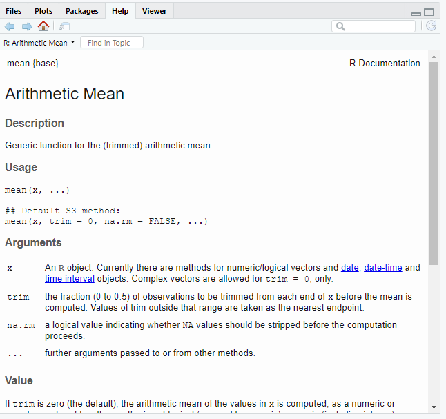

### Practice Problem:

One useful function is seq(). It creates a sequence of numbers, kind of like ‘:’ does.

```r
number_sequence=seq(1:10)
number_sequence
```

```
##  [1]  1  2  3  4  5  6  7  8  9 10
```

But, seq() can make trickier sequences, too…

For practice, use the seq() function in R to calculate the sum of all the even numbers between 0 and 1 million. (0+2+4+6+8+…). After you think you’ve got it, expand the code below to see one way you could do it, and the right answer

*hint: maybe get some help from R by using ?seq*

```r
##if we look on the help page for seq(), we see that we can specify the 'by' argument, if we want. This will tell R to make our number list by some increment other than just one. So.... if we want the even #s, we can just count by 2s, starting from 0!
evens=seq(0,1000000, by=2)

##Let's check if that worked okay...
head(evens)
```

```
## [1]  0  2  4  6  8 10
```

```r
##And now let's compute the sum!
sum(evens)
```

```
## [1] 250000500000
```

## Lesson 4: Each object has a class

Before we finish with objects and functions, I should mention that every object in R has a class. Examples of classes are logical, numeric, character, and list. An object’s class is the way that R describes the stuff inside of it

Classes are important, because R is only willing to use certain functions on certain classes:

- EX: R will not do math on characters. R is really good at math, but even R has not figured out how compute: “blueberry + Chicago”

We can check the class of something using the class() function

```r
class(a)
```

```
## [1] "numeric"
```

```r
class(vector1)
```

```
## [1] "integer"
```

```r
class(number_sequence)
```

```
## [1] "integer"
```

```r
class(2>3)
```

```
## [1] "logical"
```

What about our vector3 that has words and numbers?

```r
class(vector3)
```

```
## [1] "character"
```

It’s a character, so we can’t do mathematical operations on it!

But notice that R has converted the number 40 in vector3 to a character

```r
vector3
```

```
## [1] "40"     "carrot" "banana" NA
```

Why is this happening?

$\rightarrow$ When you make a list (vector) in R, R wants all of the entries in that list to be the same class, so that it can assign that class to the whole object. If you try to give R a vector with different types of entries, R will *help* you by ‘coercing’ all of the entries to the same class.

- In this case, since R can’t find a way to convert ‘banana’ to a number, it only has one option: it has to convert the number 40 to the text string ‘40’

(Note: Whether or not this is actually helpful will depend on your situation. Every R user has a story about how R’s ‘help’ has ruined some otherwise good code.)

# Using Packages

R is really useful because of its ability to use *packages*.

- Additional software, functions, data, etc. that someone has programmed to be used in R.

## Lesson 5: Installing and Loading Packages:

To use a package, we need to

1. Install the package (download it to our device)

```r
install.packages("package_name_goes_here_with_quotes")
```

Once a package is installed on your device, you normally don’t need to install it again.

2. Load the package (tell R to load it into the current R session)

```r
library(package_name_goes_here_without_quotes)
```

You’ll need to reload packages each time you re-open RStudio.

### Why use a package?

The big benefit of packages is that they let us avoid extra work. Instead of figuring out how to get R to do something complicated or time consuming, there may be a package that someone has already written that will do that work for us faster.

For instance. Say we need to load 20 packages into R. Using library(), this would take a bit of typing!

- (And what if we can’t remember if we’ve already installed all 20 packages?)

Pacman is a package for “package management” - it helps us load multiple packages at once. Let’s install and use it:

```r
##install the package
install.packages("pacman")
##load the package
library(pacman)
```

All of my R scripts always start with the line library(pacman).

- Then I can just use the primary function from the pacman package: *p_load()*

p_load() loads any packages you want for you, and also installs those packages if it doesn’t find them on your computer

- NOTE: When p_load does need to install/load new packages on the lab computers, it can take a bit of time.

```r
p_load(tidyverse)
```

- also cool: the p_load function can load/install as many packages as we want:

```r
#We just need the tidyverse package today, but these other
# packages aren't bad to have either.
p_load(tidyverse, haven, ggplot2)
```

# Lesson 6: The Tidyverse

The package we just installed, *tidyverse*, is actually a whole set of packages wrapped together. These packages all come wrapped together because they help serve a common purpose:

$rightarrow$ they facilitate making datasets ‘tidy,’ so that R can work with them more easily.

We need a dataframe to start with, so we’re going to use some data that comes with the tidyverse package. Let’s give it a name so we can work with it:

```r
our_data <- starwars
```

We can view our data frame by typing *view(data)* or by clicking the name in the environment tab. This will pop out something like a spreadsheet in a new tab:

```r
view(our_data)
```

```
## # A tibble: 87 x 14
##    name    height  mass hair_color  skin_color eye_color birth_year sex   gender
##    <chr>    <int> <dbl> <chr>       <chr>      <chr>          <dbl> <chr> <chr>
##  1 Luke S~    172    77 blond       fair       blue            19   male  mascu~
##  2 C-3PO      167    75 <NA>        gold       yellow         112   none  mascu~
##  3 R2-D2       96    32 <NA>        white, bl~ red             33   none  mascu~
##  4 Darth ~    202   136 none        white      yellow          41.9 male  mascu~
##  5 Leia O~    150    49 brown       light      brown           19   fema~ femin~
##  6 Owen L~    178   120 brown, grey light      blue            52   male  mascu~
##  7 Beru W~    165    75 brown       light      blue            47   fema~ femin~
##  8 R5-D4       97    32 <NA>        white, red red             NA   none  mascu~
##  9 Biggs ~    183    84 black       light      brown           24   male  mascu~
## 10 Obi-Wa~    182    77 auburn, wh~ fair       blue-gray       57   male  mascu~
## # ... with 77 more rows, and 5 more variables: homeworld <chr>, species <chr>,
## #   films <list>, vehicles <list>, starships <list>
```

We can also look at names of variables in our data using the *name()* function:

```r
names(our_data)
```

```
##  [1] "name"       "height"     "mass"       "hair_color" "skin_color"
##  [6] "eye_color"  "birth_year" "sex"        "gender"     "homeworld"
## [11] "species"    "films"      "vehicles"   "starships"
```

Tidyverse is a huge set of packages, but today we will be focusing on functions from the dplyr package:

- select(): subset columns
- filter(): subset rows on conditions
- arrange(): sort results
- mutate(): create new columns by using information from other columns
- group_by() and then summarize(): create summary statistics on grouped data
- count(): count discrete values

### Select and Filter

Let’s select only the name, gender, and homeworld variables from *our_data*

```r
select(our_data, c(name, gender, homeworld))
```

```
## # A tibble: 87 x 3
##    name               gender    homeworld
##    <chr>              <chr>     <chr>
##  1 Luke Skywalker     masculine Tatooine
##  2 C-3PO              masculine Tatooine
##  3 R2-D2              masculine Naboo
##  4 Darth Vader        masculine Tatooine
##  5 Leia Organa        feminine  Alderaan
##  6 Owen Lars          masculine Tatooine
##  7 Beru Whitesun lars feminine  Tatooine
##  8 R5-D4              masculine Tatooine
##  9 Biggs Darklighter  masculine Tatooine
## 10 Obi-Wan Kenobi     masculine Stewjon
## # ... with 77 more rows
```

Notice that this didn’t save anything in our global environment! If you want to save this new dataframe, you have to give it a name!

To select all columns except a certain one, use a minus sign:

```r
select(our_data, c(-starships, -vehicles))
```

```
## # A tibble: 87 x 12
##    name    height  mass hair_color  skin_color eye_color birth_year sex   gender
##    <chr>    <int> <dbl> <chr>       <chr>      <chr>          <dbl> <chr> <chr>
##  1 Luke S~    172    77 blond       fair       blue            19   male  mascu~
##  2 C-3PO      167    75 <NA>        gold       yellow         112   none  mascu~
##  3 R2-D2       96    32 <NA>        white, bl~ red             33   none  mascu~
##  4 Darth ~    202   136 none        white      yellow          41.9 male  mascu~
##  5 Leia O~    150    49 brown       light      brown           19   fema~ femin~
##  6 Owen L~    178   120 brown, grey light      blue            52   male  mascu~
##  7 Beru W~    165    75 brown       light      blue            47   fema~ femin~
##  8 R5-D4       97    32 <NA>        white, red red             NA   none  mascu~
##  9 Biggs ~    183    84 black       light      brown           24   male  mascu~
## 10 Obi-Wa~    182    77 auburn, wh~ fair       blue-gray       57   male  mascu~
## # ... with 77 more rows, and 3 more variables: homeworld <chr>, species <chr>,
## #   films <list>
```

If we want to filter the data in some way:

```r
# Filter the data frame to include only droids
filter(our_data, species == "Droid")
```

```
## # A tibble: 6 x 14
##   name   height  mass hair_color skin_color  eye_color birth_year sex   gender
##   <chr>   <int> <dbl> <chr>      <chr>       <chr>          <dbl> <chr> <chr>
## 1 C-3PO     167    75 <NA>       gold        yellow           112 none  masculi~
## 2 R2-D2      96    32 <NA>       white, blue red               33 none  masculi~
## 3 R5-D4      97    32 <NA>       white, red  red               NA none  masculi~
## 4 IG-88     200   140 none       metal       red               15 none  masculi~
## 5 R4-P17     96    NA none       silver, red red, blue         NA none  feminine
## 6 BB8        NA    NA none       none        black             NA none  masculi~
## # ... with 5 more variables: homeworld <chr>, species <chr>, films <list>,
## #   vehicles <list>, starships <list>
```

```r
# Filter the data frame to include droids OR humans
filter(our_data, species == "Droid" | species == "Human")
```

```
## # A tibble: 41 x 14
##    name    height  mass hair_color  skin_color eye_color birth_year sex   gender
##    <chr>    <int> <dbl> <chr>       <chr>      <chr>          <dbl> <chr> <chr>
##  1 Luke S~    172    77 blond       fair       blue            19   male  mascu~
##  2 C-3PO      167    75 <NA>        gold       yellow         112   none  mascu~
##  3 R2-D2       96    32 <NA>        white, bl~ red             33   none  mascu~
##  4 Darth ~    202   136 none        white      yellow          41.9 male  mascu~
##  5 Leia O~    150    49 brown       light      brown           19   fema~ femin~
##  6 Owen L~    178   120 brown, grey light      blue            52   male  mascu~
##  7 Beru W~    165    75 brown       light      blue            47   fema~ femin~
##  8 R5-D4       97    32 <NA>        white, red red             NA   none  mascu~
##  9 Biggs ~    183    84 black       light      brown           24   male  mascu~
## 10 Obi-Wa~    182    77 auburn, wh~ fair       blue-gray       57   male  mascu~
## # ... with 31 more rows, and 5 more variables: homeworld <chr>, species <chr>,
## #   films <list>, vehicles <list>, starships <list>
```

```r
# Filter the data frame to include characters taller than 100 cm and with a mass over 100 kg
filter(our_data, height > 100 & mass > 100)
```

```
## # A tibble: 10 x 14
##    name    height  mass hair_color  skin_color eye_color birth_year sex   gender
##    <chr>    <int> <dbl> <chr>       <chr>      <chr>          <dbl> <chr> <chr>
##  1 Darth ~    202   136 none        white      yellow          41.9 male  mascu~
##  2 Owen L~    178   120 brown, grey light      blue            52   male  mascu~
##  3 Chewba~    228   112 brown       unknown    blue           200   male  mascu~
##  4 Jabba ~    175  1358 <NA>        green-tan~ orange         600   herm~ mascu~
##  5 Jek To~    180   110 brown       fair       blue            NA   male  mascu~
##  6 IG-88      200   140 none        metal      red             15   none  mascu~
##  7 Bossk      190   113 none        green      red             53   male  mascu~
##  8 Dexter~    198   102 none        brown      yellow          NA   male  mascu~
##  9 Grievo~    216   159 none        brown, wh~ green, y~       NA   male  mascu~
## 10 Tarfful    234   136 brown       brown      blue            NA   male  mascu~
## # ... with 5 more variables: homeworld <chr>, species <chr>, films <list>,
## #   vehicles <list>, starships <list>
```

## Lesson 6.5: Pipes

Before we get further into the Tidyverse, I want to talk about pipes. You may have already noticed that we might want to use the functions from the tidyverse together. What if we want to do more than one thing all in one step???

The pipe symbol ‘%>%’ lets us chain functions together

- The pipe connects the LHS to the RHS. (Like reading a book)
- You can think about this like a conveyor belt between machines in a factory: $\rightarrow$ Each machine does something to our object, then we use a conveyer belt (a pipe) to take whatever a machine spits out, and send it to the next machine to do some further work

Let’s make/save a new dataframe where we select the name, height, and mass, then filter out those who are shorter than 100 cm:

```r
new_df <- our_data %>% select(name, height, mass) %>% filter(height >= 100)
new_df
```

```
## # A tibble: 74 x 3
##    name               height  mass
##    <chr>               <int> <dbl>
##  1 Luke Skywalker        172    77
##  2 C-3PO                 167    75
##  3 Darth Vader           202   136
##  4 Leia Organa           150    49
##  5 Owen Lars             178   120
##  6 Beru Whitesun lars    165    75
##  7 Biggs Darklighter     183    84
##  8 Obi-Wan Kenobi        182    77
##  9 Anakin Skywalker      188    84
## 10 Wilhuff Tarkin        180    NA
## # ... with 64 more rows
```

Self check: Using pipes and the tidyverse, make a new data frame where you select all columns except gender and has characters that appear ONLY in the film “A New Hope”. As before, you can click on the ’ *code* ’ button to get the answer.

```r
example_df <- our_data %>% select(-gender) %>% filter(films == "A New Hope")
```

## Back to the Tidyverse

With that quick intro to pipes, we’re ready to move deeper into the Tidyverse.

We can use *arrage* to order our data by some value. For instance, we can sort all of the characters in *our_data* by their height:

```r
our_data %>% arrange(height)
```

```
## # A tibble: 87 x 14
##    name     height  mass hair_color skin_color eye_color birth_year sex   gender
##    <chr>     <int> <dbl> <chr>      <chr>      <chr>          <dbl> <chr> <chr>
##  1 Yoda         66    17 white      green      brown            896 male  mascu~
##  2 Ratts T~     79    15 none       grey, blue unknown           NA male  mascu~
##  3 Wicket ~     88    20 brown      brown      brown              8 male  mascu~
##  4 Dud Bolt     94    45 none       blue, grey yellow            NA male  mascu~
##  5 R2-D2        96    32 <NA>       white, bl~ red               33 none  mascu~
##  6 R4-P17       96    NA none       silver, r~ red, blue         NA none  femin~
##  7 R5-D4        97    32 <NA>       white, red red               NA none  mascu~
##  8 Sebulba     112    40 none       grey, red  orange            NA male  mascu~
##  9 Gasgano     122    NA none       white, bl~ black             NA male  mascu~
## 10 Watto       137    NA black      blue, grey yellow            NA male  mascu~
## # ... with 77 more rows, and 5 more variables: homeworld <chr>, species <chr>,
## #   films <list>, vehicles <list>, starships <list>
```

```r
# Notice this does lowest to highest, we can do the other way too:
our_data %>% arrange(desc(height))
```

```
## # A tibble: 87 x 14
##    name    height  mass hair_color skin_color  eye_color birth_year sex   gender
##    <chr>    <int> <dbl> <chr>      <chr>       <chr>          <dbl> <chr> <chr>
##  1 Yarael~    264    NA none       white       yellow          NA   male  mascu~
##  2 Tarfful    234   136 brown      brown       blue            NA   male  mascu~
##  3 Lama Su    229    88 none       grey        black           NA   male  mascu~
##  4 Chewba~    228   112 brown      unknown     blue           200   male  mascu~
##  5 Roos T~    224    82 none       grey        orange          NA   male  mascu~
##  6 Grievo~    216   159 none       brown, whi~ green, y~       NA   male  mascu~
##  7 Taun We    213    NA none       grey        black           NA   fema~ femin~
##  8 Rugor ~    206    NA none       green       orange          NA   male  mascu~
##  9 Tion M~    206    80 none       grey        black           NA   male  mascu~
## 10 Darth ~    202   136 none       white       yellow          41.9 male  mascu~
## # ... with 77 more rows, and 5 more variables: homeworld <chr>, species <chr>,
## #   films <list>, vehicles <list>, starships <list>
```

Self check: Arrange the characters names in alphabetical order

```r
our_data %>% arrange(name)
```

```
## # A tibble: 87 x 14
##    name    height  mass hair_color skin_color  eye_color birth_year sex   gender
##    <chr>    <int> <dbl> <chr>      <chr>       <chr>          <dbl> <chr> <chr>
##  1 Ackbar     180    83 none       brown mott~ orange          41   male  mascu~
##  2 Adi Ga~    184    50 none       dark        blue            NA   fema~ femin~
##  3 Anakin~    188    84 blond      fair        blue            41.9 male  mascu~
##  4 Arvel ~     NA    NA brown      fair        brown           NA   male  mascu~
##  5 Ayla S~    178    55 none       blue        hazel           48   fema~ femin~
##  6 Bail P~    191    NA black      tan         brown           67   male  mascu~
##  7 Barris~    166    50 black      yellow      blue            40   fema~ femin~
##  8 BB8         NA    NA none       none        black           NA   none  mascu~
##  9 Ben Qu~    163    65 none       grey, gree~ orange          NA   male  mascu~
## 10 Beru W~    165    75 brown      light       blue            47   fema~ femin~
## # ... with 77 more rows, and 5 more variables: homeworld <chr>, species <chr>,
## #   films <list>, vehicles <list>, starships <list>
```

You’ll end up using *mutate* a lot, since it lets us make new variables from old ones. Let’s create a new variable that measures height in inches instead of centimeters - (2.54cm = 1 inch)

```r
our_data %>% mutate(height_inches = height/2.54)
```

```
## # A tibble: 87 x 15
##    name    height  mass hair_color  skin_color eye_color birth_year sex   gender
##    <chr>    <int> <dbl> <chr>       <chr>      <chr>          <dbl> <chr> <chr>
##  1 Luke S~    172    77 blond       fair       blue            19   male  mascu~
##  2 C-3PO      167    75 <NA>        gold       yellow         112   none  mascu~
##  3 R2-D2       96    32 <NA>        white, bl~ red             33   none  mascu~
##  4 Darth ~    202   136 none        white      yellow          41.9 male  mascu~
##  5 Leia O~    150    49 brown       light      brown           19   fema~ femin~
##  6 Owen L~    178   120 brown, grey light      blue            52   male  mascu~
##  7 Beru W~    165    75 brown       light      blue            47   fema~ femin~
##  8 R5-D4       97    32 <NA>        white, red red             NA   none  mascu~
##  9 Biggs ~    183    84 black       light      brown           24   male  mascu~
## 10 Obi-Wa~    182    77 auburn, wh~ fair       blue-gray       57   male  mascu~
## # ... with 77 more rows, and 6 more variables: homeworld <chr>, species <chr>,
## #   films <list>, vehicles <list>, starships <list>, height_inches <dbl>
```

Self check: Create a new variable that is the sum of person’s mass and height

```r
our_data %>% mutate(total = height + mass)
```

```
## # A tibble: 87 x 15
##    name    height  mass hair_color  skin_color eye_color birth_year sex   gender
##    <chr>    <int> <dbl> <chr>       <chr>      <chr>          <dbl> <chr> <chr>
##  1 Luke S~    172    77 blond       fair       blue            19   male  mascu~
##  2 C-3PO      167    75 <NA>        gold       yellow         112   none  mascu~
##  3 R2-D2       96    32 <NA>        white, bl~ red             33   none  mascu~
##  4 Darth ~    202   136 none        white      yellow          41.9 male  mascu~
##  5 Leia O~    150    49 brown       light      brown           19   fema~ femin~
##  6 Owen L~    178   120 brown, grey light      blue            52   male  mascu~
##  7 Beru W~    165    75 brown       light      blue            47   fema~ femin~
##  8 R5-D4       97    32 <NA>        white, red red             NA   none  mascu~
##  9 Biggs ~    183    84 black       light      brown           24   male  mascu~
## 10 Obi-Wa~    182    77 auburn, wh~ fair       blue-gray       57   male  mascu~
## # ... with 77 more rows, and 6 more variables: homeworld <chr>, species <chr>,
## #   films <list>, vehicles <list>, starships <list>, total <dbl>
```

We often use group_by and summarize together. In plain English, *group_by* lets us tell R that we want to separate our data into different chunks. This is useful, because then we can use the *summarize* function to compute summary statistics on those chunks, instead of on the whole dataset.

For instance, we could use these functions to find the average height for each species in our data:

```r
our_data %>% group_by(species) %>% summarize(avg_height = mean(height))
```

```
## # A tibble: 38 x 2
##    species   avg_height
##    <chr>          <dbl>
##  1 Aleena           79
##  2 Besalisk        198
##  3 Cerean          198
##  4 Chagrian        196
##  5 Clawdite        168
##  6 Droid            NA
##  7 Dug             112
##  8 Ewok             88
##  9 Geonosian       183
## 10 Gungan          209.
## # ... with 28 more rows
```

```r
# Notice we have NA's! We can get rid of those using the na.omit() function
our_data %>% na.omit() %>% group_by(species) %>% summarize(avg_height = mean(height))
```

```
## # A tibble: 11 x 2
##    species      avg_height
##    <chr>             <dbl>
##  1 Cerean              198
##  2 Ewok                 88
##  3 Gungan              196
##  4 Human               178
##  5 Kel Dor             188
##  6 Mirialan            168
##  7 Mon Calamari        180
##  8 Trandoshan          190
##  9 Twi'lek             178
## 10 Wookiee             228
## 11 Zabrak              175
```

Finally, the count function can tell us how many different values there are in a column.

We could use this to figure out how many species are in our data:

```r
our_data %>% count(species)
```

```
## # A tibble: 38 x 2
##    species       n
##    <chr>     <int>
##  1 Aleena        1
##  2 Besalisk      1
##  3 Cerean        1
##  4 Chagrian      1
##  5 Clawdite      1
##  6 Droid         6
##  7 Dug           1
##  8 Ewok          1
##  9 Geonosian     1
## 10 Gungan        3
## # ... with 28 more rows
```

# Lesson 7: OLS Regression in R

Since this is a metrics class, let’s wrap up with a quick intro to running regressions in R. As you should have guessed by now, we can use a function to run regressions: the *lm()* function.

To use lm(), we have to give R 2 things:

1. the formula for the regression we want
2. the data we want to run the regression with

A generic example is below:

```r
lm(dependent_variable ~ independent_variable_1 + independent_variable_2, data = name_of_df)

##Note: if we want R to save the results of this regression,
##      we need to make it an object, as above:

name=lm(dependent_variable ~ independent_variable_1 + independent_variable_2, data = name_of_df)
```

For example, let’s regress height on mass:

```r
reg1 <- lm(height ~ mass, data = our_data)

class(reg1)
```

```
## [1] "lm"
```

```r
##Notice: regression objects in R are special enough that they have their own class: "lm"
```

Note that we can also use pipes and the tidyverse with *lm()*

```r
reg2 <- lm(height ~ mass, data = our_data %>% filter(species != "Hutt"))
```

Okay, cool. But can we look at the output of our regression?

```r
##let's try it the simple way, by just calling the object
reg2
```

```
##
## Call:
## lm(formula = height ~ mass, data = our_data %>% filter(species !=
##     "Hutt"))
##
## Coefficients:
## (Intercept)         mass
##      101.67         0.95
```

…okay. That kind of helps… But R is supposed to be really good at statistics… Where are my p-values at?

We can do better. ‘lm’ objects actually have a lot of info under the hood. The lm object *does* contain things like T-values, p-values, degrees of freedom, and other cool stuff.

$\rightarrow$ The *summary()* function will extract this info for us quickly

```r
summary(reg2)
```

```
##
## Call:
## lm(formula = height ~ mass, data = our_data %>% filter(species !=
##     "Hutt"))
##
## Residuals:
##     Min      1Q  Median      3Q     Max
## -51.821  -6.273   2.327  14.078  45.728
##
## Coefficients:
##             Estimate Std. Error t value Pr(>|t|)
## (Intercept) 101.6706     8.6593  11.741  < 2e-16 ***
## mass          0.9500     0.1064   8.931 2.72e-12 ***
## ---
## Signif. codes:  0 '***' 0.001 '**' 0.01 '*' 0.05 '.' 0.1 ' ' 1
##
## Residual standard error: 23.3 on 55 degrees of freedom
##   (25 observations deleted due to missingness)
## Multiple R-squared:  0.5919, Adjusted R-squared:  0.5845
## F-statistic: 79.77 on 1 and 55 DF,  p-value: 2.72e-12
```

Before we end, try to answer these questions about *reg2* to jog your memory from your last metrics class:

1. Can you interpret the coefficient on mass from *reg2*? What about the intercept?
2. What are the null and alternative hypotheses being used to create the T-value on the mass variable?
3. Is the coefficient for mass significant at the 5% level?

(Once you’ve given this some thought, the answers are hidden below)

```r
# 1. The coefficient on mass says that with a 1 kg increase in mass, height increases by .95 cm.
#    The intercept value says that if a person weighs 0 kg, they would be ~101 cm tall

# 2. beta_1 = 0, Ha: beta_1 /= 0

# 3. Since p < .05, we reject the null hypothesis at the 5% level.
# That is, the coefficient is significant at the 5%
```